# DSCI 503 - Project 03

### Nicholas Allen

Due February 20, 2022

```python
import numpy as np, pandas as pd, matplotlib.pyplot as plt
```

## Part 1: Loading the Dataset; Preliminary Analysis

The first step is to load the data and verify we get data returned

```python
diamonds = pd.read_table('diamonds.txt', sep='\t')
diamonds.head(10)
```

|  | carat | cut | color | clarity | depth | table | price | x | y | z |
| --- | --- | --- | --- | --- | --- | --- | --- | --- | --- | --- |
| 1 | 0.23 | Ideal | E | SI2 | 61.5 | 55.0 | 326 | 3.95 | 3.98 | 2.43 |
| 2 | 0.21 | Premium | E | SI1 | 59.8 | 61.0 | 326 | 3.89 | 3.84 | 2.31 |
| 3 | 0.23 | Good | E | VS1 | 56.9 | 65.0 | 327 | 4.05 | 4.07 | 2.31 |
| 4 | 0.29 | Premium | I | VS2 | 62.4 | 58.0 | 334 | 4.20 | 4.23 | 2.63 |
| 5 | 0.31 | Good | J | SI2 | 63.3 | 58.0 | 335 | 4.34 | 4.35 | 2.75 |
| 6 | 0.24 | Very Good | J | VVS2 | 62.8 | 57.0 | 336 | 3.94 | 3.96 | 2.48 |
| 7 | 0.24 | Very Good | I | VVS1 | 62.3 | 57.0 | 336 | 3.95 | 3.98 | 2.47 |
| 8 | 0.26 | Very Good | H | SI1 | 61.9 | 55.0 | 337 | 4.07 | 4.11 | 2.53 |
| 9 | 0.22 | Fair | E | VS2 | 65.1 | 61.0 | 337 | 3.87 | 3.78 | 2.49 |
| 10 | 0.23 | Very Good | H | VS1 | 59.4 | 61.0 | 338 | 4.00 | 4.05 | 2.39 |

Below we will return the size of the dataset

```python
diamonds.shape
```

```
(53940, 10)
```

Next we explore the some summary statististics for the diamonds dataframe

```python
diamonds.describe()
```

|  | carat | depth | table | price | x | y | z |
| --- | --- | --- | --- | --- | --- | --- | --- |
| count | 53940.000000 | 53940.000000 | 53940.000000 | 53940.000000 | 53940.000000 | 53940.000000 | 53940.000000 |
| mean | 0.797940 | 61.749405 | 57.457184 | 3932.799722 | 5.731157 | 5.734526 | 3.538734 |
| std | 0.474011 | 1.432621 | 2.234491 | 3989.439738 | 1.121761 | 1.142135 | 0.705699 |
| min | 0.200000 | 43.000000 | 43.000000 | 326.000000 | 0.000000 | 0.000000 | 0.000000 |
| 25% | 0.400000 | 61.000000 | 56.000000 | 950.000000 | 4.710000 | 4.720000 | 2.910000 |
| 50% | 0.700000 | 61.800000 | 57.000000 | 2401.000000 | 5.700000 | 5.710000 | 3.530000 |
| 75% | 1.040000 | 62.500000 | 59.000000 | 5324.250000 | 6.540000 | 6.540000 | 4.040000 |
| max | 5.010000 | 79.000000 | 95.000000 | 18823.000000 | 10.740000 | 58.900000 | 31.800000 |

## Part 2: Filtering and Sorting

Now we display code to output the 5 most expensive diamonds, for further visual inspection of data

```python
diamonds.loc[:,['price','carat','cut','color','clarity']].sort_values(by='price', ascending=False).head(5)
```

|  | price | carat | cut | color | clarity |
| --- | --- | --- | --- | --- | --- |
| 27750 | 18823 | 2.29 | Premium | I | VS2 |
| 27749 | 18818 | 2.00 | Very Good | G | SI1 |
| 27748 | 18806 | 1.51 | Ideal | G | IF |
| 27747 | 18804 | 2.07 | Ideal | G | SI2 |
| 27746 | 18803 | 2.00 | Very Good | H | SI1 |

Next we will view the 5 least expensive diamonds

```python
diamonds.loc[:,['price','carat','cut','color','clarity']].sort_values(by='price', ascending=True).head(5)
```

|  | price | carat | cut | color | clarity |
| --- | --- | --- | --- | --- | --- |
| 1 | 326 | 0.23 | Ideal | E | SI2 |
| 2 | 326 | 0.21 | Premium | E | SI1 |
| 3 | 327 | 0.23 | Good | E | VS1 |
| 4 | 334 | 0.29 | Premium | I | VS2 |
| 5 | 335 | 0.31 | Good | J | SI2 |

Now we will investigate the 5 largest 'ideal cut' diamonds

```python
mask=diamonds.loc[:,'cut']=='Ideal'
diamonds.loc[mask,['price','carat','cut','color','clarity']].sort_values(by='carat', ascending=False).head(5)
```

|  | price | carat | cut | color | clarity |
| --- | --- | --- | --- | --- | --- |
| 24329 | 12587 | 3.50 | Ideal | H | I1 |
| 24298 | 12545 | 3.22 | Ideal | I | I1 |
| 26468 | 16037 | 3.01 | Ideal | J | SI2 |
| 26745 | 16538 | 3.01 | Ideal | J | I1 |
| 24785 | 13156 | 2.75 | Ideal | D | I1 |

Now we will investigate the 5 largest 'fair cut' diamonds

```python
mask=diamonds.loc[:,'cut']=='Fair'
diamonds.loc[mask,['price','carat','cut','color','clarity']].sort_values(by='carat', ascending=False).head(5)
```

|  | price | carat | cut | color | clarity |
| --- | --- | --- | --- | --- | --- |
| 27416 | 18018 | 5.01 | Fair | J | I1 |
| 27631 | 18531 | 4.50 | Fair | J | I1 |
| 27131 | 17329 | 4.13 | Fair | H | I1 |
| 23645 | 11668 | 3.65 | Fair | H | I1 |
| 26432 | 15964 | 3.40 | Fair | D | I1 |

## Part 3: Working with Categorical Variables

```python
clarity_levels = ['I1','SI2','SI1','VS2','VS1','VVS2','VVS1','IF']
cut_levels = ['J','I','H','G','F','E','D']
color_levels = ['Fair','Good','Very Good','Ideal','Premium']
```

```python
diamonds.clarity = pd.Categorical(diamonds.clarity, clarity_levels)
diamonds.color = pd.Categorical(diamonds.color, color_levels)
diamonds.cut = pd.Categorical(diamonds.cut, cut_levels)
```

Below contains a list of colors that will be utilized in later data visualizations

```python
clarity_pal = ['b','g','r','c','m','yellow','orange','purple']
cut_pal = ['b','g','r','c','m','yellow','orange',]
color_pal =['b','g','r','c','m',]
```

## Part 4: Displaying Counts for Categorical Variables

In this section we begin by counting the number of diamonds for each cut

```python
mask=diamonds.loc[:,'cut']=='Fair'
temp = diamonds.loc[mask,['price','carat','cut','color','clarity']].value_counts().sort_index()
temp
```

```
Series([], dtype: int64)
```

```python
diamonds.cut.value_counts().sort_index()
```

```
J    0
I    0
H    0
G    0
F    0
E    0
D    0
Name: cut, dtype: int64
```

Next we count the number of diamonds of each color

```python
diamonds.color.value_counts()
```

```
Fair         0
Good         0
Very Good    0
Ideal        0
Premium      0
Name: color, dtype: int64
```

Thirdly we perform the same action to count the diamonds of each type of clarity

```python
diamonds.clarity.value_counts().sort_index()
```

```
I1        741
SI2      9194
SI1     13065
VS2     12258
VS1      8171
VVS2     5066
VVS1     3655
IF       1790
Name: clarity, dtype: int64
```

## Part 5: Scatterplots of Price Against Carat

This problem probes the correltation between price and carat using scatter plots

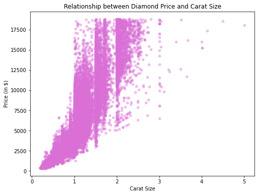

```python
plt.figure(figsize=[8,6])
plt.scatter(x=diamonds.loc[:,'carat'], y=diamonds.loc[:,'price'], s=20, alpha=0.4,
            color='orchid')
plt.xlabel('Carat Size')
plt.ylabel('Price (in $)')
plt.title('Relationship between Diamond Price and Carat Size')
plt.show()
```

Below we expand upon the plot by incorporating diamond clarity as a categorical variable represented by the color of the point.

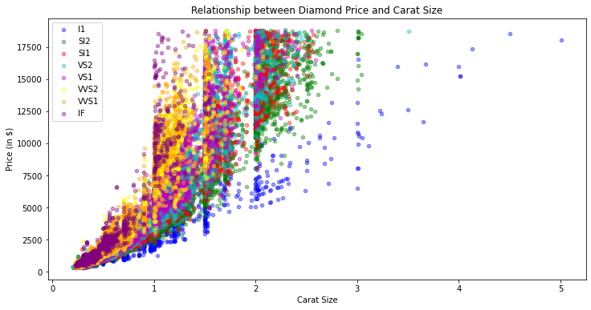

```python
plt.figure(figsize=[12,6])
for i in range(len(clarity_pal)):
    plt.scatter(x=diamonds.loc[diamonds.loc[:,'clarity']==clarity_levels[i],'carat'], y=diamonds.loc[diamonds.loc[:,'clarity']==clarity_levels[i],'price'], s=20, alpha=0.4,
            color=clarity_pal[i], label=clarity_levels[i])
plt.xlabel('Carat Size')
plt.ylabel('Price (in $)')
plt.title('Relationship between Diamond Price and Carat Size')
plt.legend()
plt.show()
```

The below group of plots display the same relationship but breakout subplots according to clarity levels.

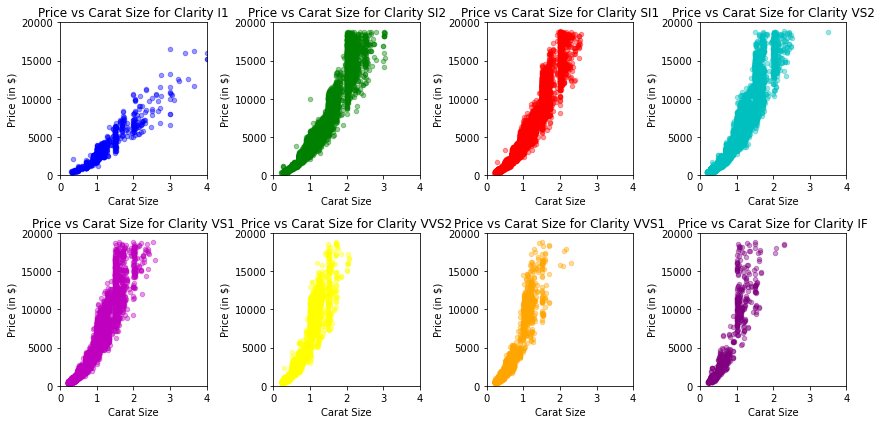

```python
plt.figure(figsize=[12,6])

for i in range(len(clarity_pal)):
    plt.subplot(2,4,i+1)
    plt.scatter(x=diamonds.loc[diamonds.loc[:,'clarity']==clarity_levels[i],'carat'], y=diamonds.loc[diamonds.loc[:,'clarity']==clarity_levels[i],'price'], s=20, alpha=0.4,
            color=clarity_pal[i], label=clarity_levels[i])
    plt.xlabel('Carat Size')
    plt.ylabel('Price (in $)')
    plt.title('Price vs Carat Size for Clarity '+clarity_levels[i])
    plt.xlim([0,4])
    plt.ylim([0,20000])
    plt.tight_layout()
plt.show()
```

## Part 6: Applying Logarithmic Transformations

Now we will explore the same price v carat relationship but using logarithmic transformations. This begins by adding two columns to the diamonds dataframe so we can store the transformed data.

```python
diamonds.loc[:,'ln_carat']=np.log(diamonds.loc[:,'carat'])
diamonds.loc[:,'ln_price']=np.log(diamonds.loc[:,'price'])
```

Below are the histograms to explore the price carat relationship for our transformed variables

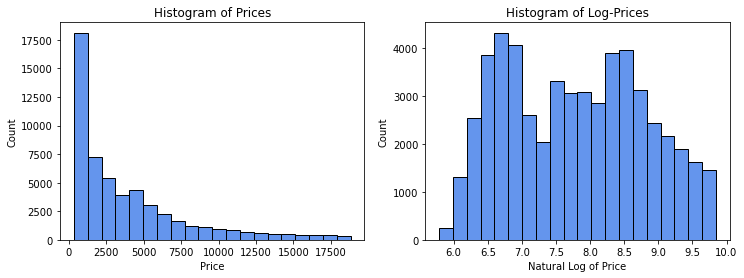

```python
plt.figure(figsize=[12,4])
plt.subplot(1,2,1)
plt.hist(diamonds.loc[:,'price'],edgecolor='black', color='cornflowerblue', bins=20)
plt.xlabel('Price')
plt.ylabel('Count')
plt.title('Histogram of Prices')

plt.subplot(1,2,2)
plt.hist(diamonds.loc[:,'ln_price'],edgecolor='black', color='cornflowerblue', bins=20)
plt.xlabel('Natural Log of Price')
plt.ylabel('Count')
plt.title('Histogram of Log-Prices')
plt.show()
```

we now perform the same data visualization for the carats and natural log of carats

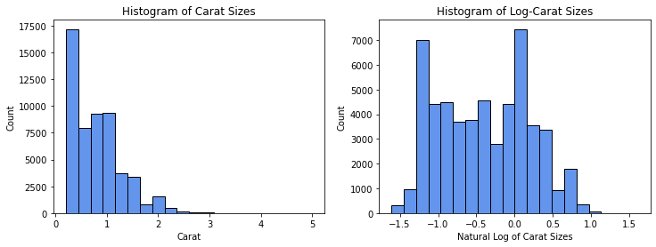

```python
plt.figure(figsize=[12,4])
plt.subplot(1,2,1)
plt.hist(diamonds.loc[:,'carat'],edgecolor='black', color='cornflowerblue', bins=20)
plt.xlabel('Carat')
plt.ylabel('Count')
plt.title('Histogram of Carat Sizes')

plt.subplot(1,2,2)
plt.hist(diamonds.loc[:,'ln_carat'],edgecolor='black', color='cornflowerblue', bins=20)
plt.xlabel('Natural Log of Carat Sizes')
plt.ylabel('Count')
plt.title('Histogram of Log-Carat Sizes')
plt.show()
```

## Part 7: Scatterplot of Transformed Variables

Similar to Part 5, we will now display the transformed variables in a scatter plot displaying clarity values as categorical colors

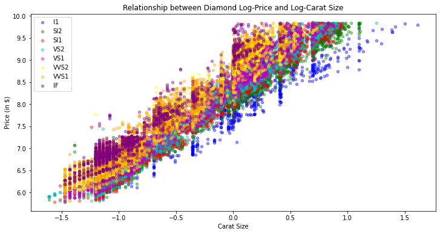

```python
plt.figure(figsize=[12,6])
for i in range(len(clarity_pal)):
    plt.scatter(x=diamonds.loc[diamonds.loc[:,'clarity']==clarity_levels[i],'ln_carat'], y=diamonds.loc[diamonds.loc[:,'clarity']==clarity_levels[i],'ln_price'], s=20, alpha=0.4,
            color=clarity_pal[i], label=clarity_levels[i])
plt.xlabel('Carat Size')
plt.ylabel('Price (in $)')
plt.title('Relationship between Diamond Log-Price and Log-Carat Size')
plt.legend()
plt.show()
```

## Part 8: Grouping by Cut

Below is a grouped dataframe to show mean price and carat size for each cut

```python
gb_cut = diamonds.loc[:,['cut', 'price', 'carat']].groupby('cut').mean()
gb_cut
```

| cut | price | carat |
| --- | --- | --- |
| J | NaN | NaN |
| I | NaN | NaN |
| H | NaN | NaN |
| G | NaN | NaN |
| F | NaN | NaN |
| E | NaN | NaN |
| D | NaN | NaN |

We will use bar charts to visusalize the data we have just created

[figure not shown]

```python
plt.figure(figsize=[12,4])
plt.subplot(1,2,1)
plt.bar(gb_cut.index,gb_cut.loc[:,'price'], color=cut_pal, edgecolor='black')
plt.xlabel('Cut')
plt.ylabel('Mean Price')
plt.title('Mean Price by Cut')

plt.subplot(1,2,2)
plt.bar(gb_cut.index,gb_cut.loc[:,'carat'], color=cut_pal, edgecolor='black')
plt.xlabel('Cut')
plt.ylabel('Mean Carat Size')
plt.title('Mean Carat Size by Cut')
plt.show()
```

## Part 9: Grouping by Color

Building off part 8, we will create a dataframe to show mean price and carat size by color

```python
gb_color = diamonds.loc[:,['color', 'price', 'carat']].groupby('color').mean()
gb_color
```

| color | price | carat |
| --- | --- | --- |
| Fair | NaN | NaN |
| Good | NaN | NaN |
| Very Good | NaN | NaN |
| Ideal | NaN | NaN |
| Premium | NaN | NaN |

We will use bar charts to visusalize the color data we have just created

[figure not shown]

```python
plt.figure(figsize=[12,4])
plt.subplot(1,2,1)
plt.bar(gb_color.index,gb_color.loc[:,'price'], color=color_pal, edgecolor='black')
plt.xlabel('Color')
plt.ylabel('Mean Price')
plt.title('Mean Price by Color')

plt.subplot(1,2,2)
plt.bar(gb_color.index,gb_color.loc[:,'carat'], color=color_pal, edgecolor='black')
plt.xlabel('Color')
plt.ylabel('Mean Carat Size')
plt.title('Mean Carat Size by Color')
plt.show()
```

## Part 10: Grouping by Clarity

```python
gb_clarity = diamonds.loc[:,['clarity', 'price', 'carat']].groupby('clarity').mean()
gb_clarity
```

| clarity | price | carat |
| --- | --- | --- |
| I1 | 3924.168691 | 1.283846 |
| SI2 | 5063.028606 | 1.077648 |
| SI1 | 3996.001148 | 0.850482 |
| VS2 | 3924.989395 | 0.763935 |
| VS1 | 3839.455391 | 0.727158 |
| VVS2 | 3283.737071 | 0.596202 |
| VVS1 | 2523.114637 | 0.503321 |
| IF | 2864.839106 | 0.505123 |

We will use bar charts to visusalize the clarity data we have just created

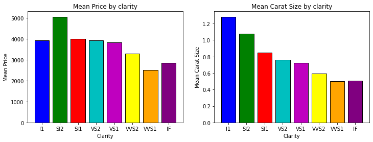

```python
plt.figure(figsize=[12,4])
plt.subplot(1,2,1)
plt.bar(gb_clarity.index,gb_clarity.loc[:,'price'], color=clarity_pal, edgecolor='black')
plt.xlabel('Clarity')
plt.ylabel('Mean Price')
plt.title('Mean Price by clarity')

plt.subplot(1,2,2)
plt.bar(gb_clarity.index,gb_clarity.loc[:,'carat'], color=clarity_pal, edgecolor='black')
plt.xlabel('Clarity')
plt.ylabel('Mean Carat Size')
plt.title('Mean Carat Size by clarity')
plt.show()
```